# PA1_template

Imad-Alhiane

2024-09-15

# Reproducible Research, Course Project 1

## Introduction

In this project, we analyze data collected from a personal activity monitoring device that records the number of steps taken by an individual at 5-minute intervals throughout the day. The data spans two months (October and November 2012) and allows us to explore patterns in physical activity. This analysis is part of the “quantified self” movement, which emphasizes the collection of personal data to improve health and self-awareness.

The main objectives are to:

Summarize the total number of steps taken per day.

Visualize the distribution of daily step counts.

Explore average activity patterns.

Handle missing data by imputing steps based on averages for specific intervals.

Compare activity patterns between weekdays and weekends.

## Code Explanation:

1. Loading the Data: The data is first unzipped and loaded from a CSV file. The date column is converted to Date format for easier handling of time-based analysis.

```r
# unzip(zipfile="activity.zip")
df <- read.csv("activity.csv")
df$date <- as.Date(df$date, format = "%Y-%m-%d")
```

2. Summing Steps Per Day: We calculate the total number of steps per day using the tapply() function, ignoring missing (NA) values. This data is converted into a data frame (steps_per_day_df) for further processing.

```r
steps_per_day <- tapply(df$steps, df$date, sum, na.rm = TRUE)
steps_per_day_df <- data.frame(date = names(steps_per_day), steps = as.vector(steps_per_day))
```

3. Visualizing Steps Per Day: We plot a histogram of the total steps per day using ggplot2. The plot includes vertical lines showing the mean and median step counts for each day. The lines are colored red and blue for the mean and median, respectively.

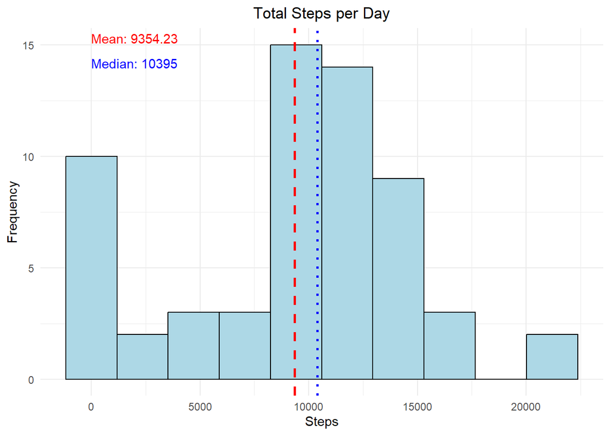

```r
# Load the ggplot2 library for plotting
library(ggplot2)

# Calculate the mean and median steps per day
mean_val <- mean(steps_per_day, na.rm = TRUE)
median_val <- median(steps_per_day, na.rm = TRUE)

# Plot a histogram of the steps per day with mean and median lines
ggplot(steps_per_day_df, aes(x = steps)) +
  geom_histogram(bins = 10, fill = "lightblue", color = "black") +
  geom_vline(aes(xintercept = mean_val), color = "red", linetype = "dashed", linewidth = 1) +  # Red dashed line for mean
  geom_vline(aes(xintercept = median_val), color = "blue", linetype = "dotted", linewidth = 1) +  # Blue dotted line for median
  labs(title = "Total Steps per Day", x = "Steps", y = "Frequency") +  # Axis labels and title
  theme_minimal() +
  theme(plot.title = element_text(hjust = 0.5)) +  # Center-align the title
  # Annotate the histogram with mean and median values
  annotate("text", x = min(steps_per_day_df$steps, na.rm = TRUE),
           y = Inf, label = paste("Mean:", round(mean_val, 2)), color = "red", hjust = 0, vjust = 1.5) +
  annotate("text", x = min(steps_per_day_df$steps, na.rm = TRUE),
           y = Inf, label = paste("Median:", round(median_val, 2)), color = "blue", hjust = 0, vjust = 4)
```

4. Calculating Average Steps per 5-Minute Interval: Using the aggregate() function, we calculate the average number of steps taken during each 5-minute interval across all days. This data helps us identify patterns of activity throughout the day.

```r
averages <- aggregate(x=list(steps=df$steps), by=list(interval=df$interval), FUN=mean, na.rm=TRUE)
```

5. Highlighting Maximum Average Steps: We identify the maximum average number of steps and the corresponding 5-minute interval. This maximum value is highlighted in the plot with a red point, and a label is added to annotate it.

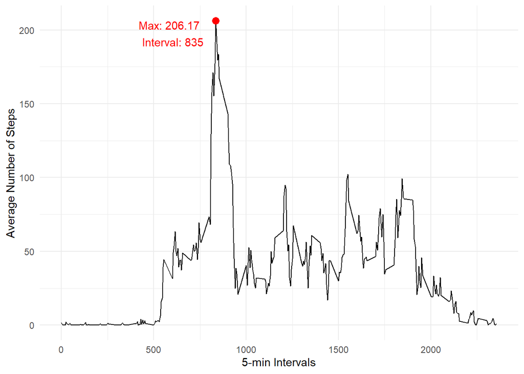

```r
# Find the maximum average steps and corresponding interval
max_value <- max(averages$steps)
max_interval <- averages$interval[which.max(averages$steps)]

# Plot the average steps per 5-min interval and highlight the max value
ggplot(data=averages, aes(x=interval, y=steps)) +
  geom_line() +
  annotate("point", x = max_interval, y = max_value, color = "red", size = 3) +  # Highlight max value with a red point
  annotate("text", x = max_interval, y = max_value, label = paste("Max:", round(max_value, 2), "\nInterval:", max_interval),
           vjust = 1, hjust = 1.2, color = "red") +  # Annotate the max value and corresponding interval
  labs(x = "5-min Intervals", y = "Average Number of Steps") +  # Axis labels
  theme_minimal()
```

6. Handling Missing Data: Many NA values exist in the dataset. We impute missing values by replacing NA in the steps column with the average steps for that specific 5-minute interval.

```r
# Handle missing data (NA values in 'steps' column)
# Count the number of missing values in the 'steps' column
missing_values <- sum(is.na(df$steps))  # Sum up the TRUE values, which represent missing values
cat("The number of missing values in the dataset:", missing_values)
```

```
## The number of missing values in the dataset: 2304
```

```r
# Fill NA values in 'steps' with the average steps for the corresponding interval
df$complet_steps <- ifelse(is.na(df$steps),
                           averages$steps[match(df$interval, averages$interval)],
                           df$steps)
```

7. Re-exploring the Steps Per Day : After filling in the missing data, we recalculate the total number of steps per day and recompute the mean and median step counts. A new histogram is plotted to visualize the updated distribution of total step.

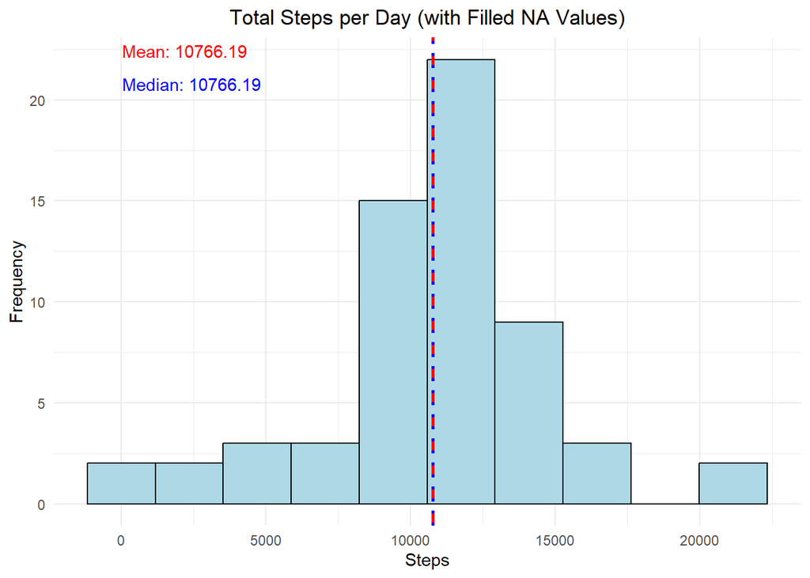

```r
# Calculate the total steps per day after filling in missing data
steps_per_day_df$complet_steps <- tapply(df$complet_steps, df$date, sum, na.rm = TRUE)

# Recalculate the mean and median with filled data
mean_val2 <- mean(steps_per_day_df$complet_steps, na.rm = TRUE)
median_val2 <- median(steps_per_day_df$complet_steps, na.rm = TRUE)

# Plot the updated histogram with mean and median lines
ggplot(steps_per_day_df, aes(x = complet_steps)) +
  geom_histogram(bins = 10, fill = "lightblue", color = "black") +
  geom_vline(aes(xintercept = mean_val2), color = "red", linetype = "dashed", linewidth = 1) +  # Mean line
  geom_vline(aes(xintercept = median_val2), color = "blue", linetype = "dotted", linewidth = 1) +  # Median line
  labs(title = "Total Steps per Day (with Filled NA Values)", x = "Steps", y = "Frequency") +  # Labels
  theme_minimal() +
  theme(plot.title = element_text(hjust = 0.5)) +  # Center-align the title
  # Annotate the histogram with updated mean and median values
  annotate("text", x = min(steps_per_day_df$complet_steps, na.rm = TRUE),
           y = Inf, label = paste("Mean:", round(mean_val2, 2)), color = "red", hjust = 0, vjust = 1.5) +
  annotate("text", x = min(steps_per_day_df$complet_steps, na.rm = TRUE),
           y = Inf, label = paste("Median:", round(median_val2, 2)), color = "blue", hjust = 0, vjust = 4)
```

The strategy adopted for handling missing data has resulted in a slight shift in the overall distribution. It has become more centralized, with the mean now equal to the median, and the distribution is trending towards a more symmetric shape.

8. Categorizing Days into Weekdays and Weekends: To analyze differences in activity between weekdays and weekends, we create a new column day_type that labels each date as either “weekday” or “weekend.”

```r
Sys.setlocale("LC_TIME", "English") # Seting locale to English
```

```
## [1] "English_United States.1252"
```

```r
# Add a new column "day_type" to indicate whether the date is a weekday or weekend
df$day_type <- ifelse(weekdays(df$date) %in% c("Saturday", "Sunday"), "weekend", "weekday")
# Convert it to a factor for better handling in plots, if necessary
df$day_type <- factor(df$day_type, levels = c("weekday", "weekend"))
```

9. Comparing Weekday and Weekend Activity Patterns: Finally, we calculate the average number of steps per 5-minute interval, separately for weekdays and weekends. We visualize these patterns using a panel plot (facet_wrap) that shows the data for weekdays and weekends in separate panels.

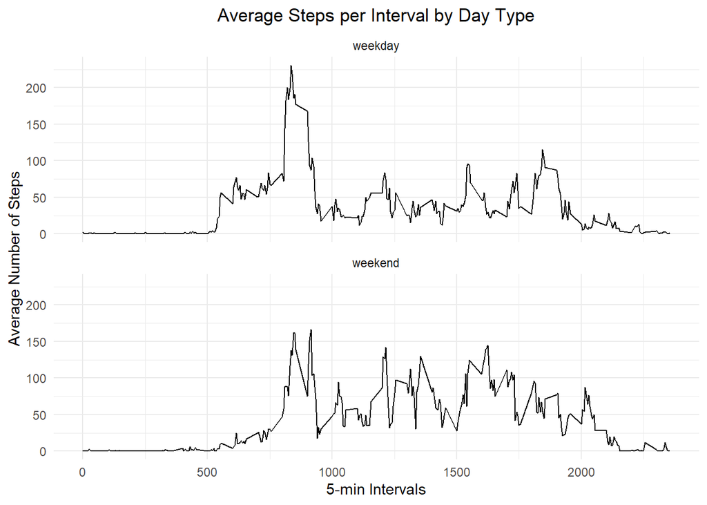

```r
# Calculate the average steps per interval separately for weekdays and weekends
averages_day_type <- aggregate(complet_steps ~ interval + day_type, data=df, FUN=mean, na.rm=TRUE)

# Plot the line graph with panels for weekday and weekend
ggplot(data=averages_day_type, aes(x=interval, y=complet_steps)) +
  geom_line() +  # Line plot for average steps per interval
  facet_wrap(~ day_type, ncol = 1) +  # Create separate panels for weekdays and weekends
  labs(x = "5-min Intervals", y = "Average Number of Steps", title = "Average Steps per Interval by Day Type") +  # Axis labels and title
  theme_minimal() +
  theme(plot.title = element_text(hjust = 0.5))  # Center the title
```